# Exponential Distribution Simulation and Comparison

### Overview

We will nvestigate the exponential distribution in R and compare it with the Central Limit Theorem.

The exponential distribution can be simulated in R with *rexp(n, lambda)* where *lambda* is the rate parameter. The mean of exponential distribution is *1/lambda* and the standard deviation is also *1/lambda*.

Lambda will be set to 0.2 for all of the simulations.

We will investigate the distribution of averages of 40 exponentials. We will need to do a thousand simulations.

The goal is to illustrate via simulation and associated explanatory text the properties of the distribution of the mean of 40 exponentials. You should:

1. Show the sample mean and compare it to the theoretical mean of the distribution.
2. Show how variable the sample is (via variance) and compare it to the theoretical variance of the distribution.
3. Show that the distribution is approximately normal.

```r
# Setup Code, include libraries.
library(ggplot2)

# Variables
sims <- 1000
lambda <- 0.2
n <- 40

# Set random seed for reproducibility.
set.seed(3737)
```

### Simulation

Create a matrix of 1000 rows by 40 columns. We will use 40 columns as the samples of the random sim.

```r
# Since a matrix fills in a cascade, this does the job of generating the
# sims and the samples.
sim_matrix <- matrix(rexp(sims * n, rate=lambda), sims, n)

# Means of the random samples.
sample_means <- rowMeans(sim_matrix)
```

Let’s plot the simulation means:

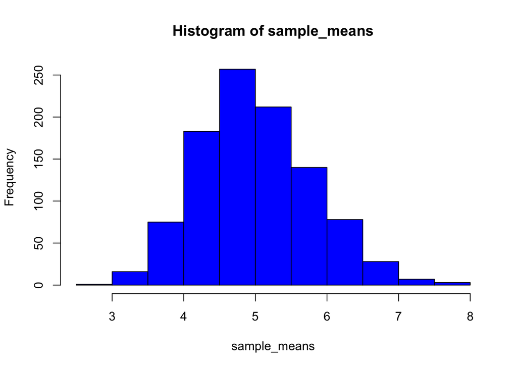

```r
hist(sample_means, col="blue")
```

### Sample Mean (Center) vs Theoretical Mean (Center)

```r
theoretical_mean <- 1/lambda
sample_mean <- mean(sample_means)
```

We can see that the theoretical mean is **5** and the mean of the samples is **5.001566**. The difference between the two is minimal - only **0.001566.** This makes the sample mean an unbiased estimator of the population mean.

```r
sample_var <- var(sample_means)
theoretical_var <- (theoretical_mean) ^ 2/n
```

### How can we tell the distribution of the sample means is approximately normal?

##### Compare to Normal Distribution

```r
normal_sim <- rnorm(1000, 0, 1)
```

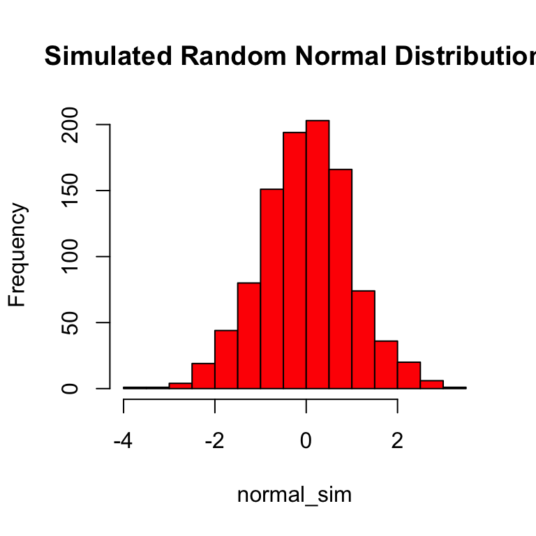

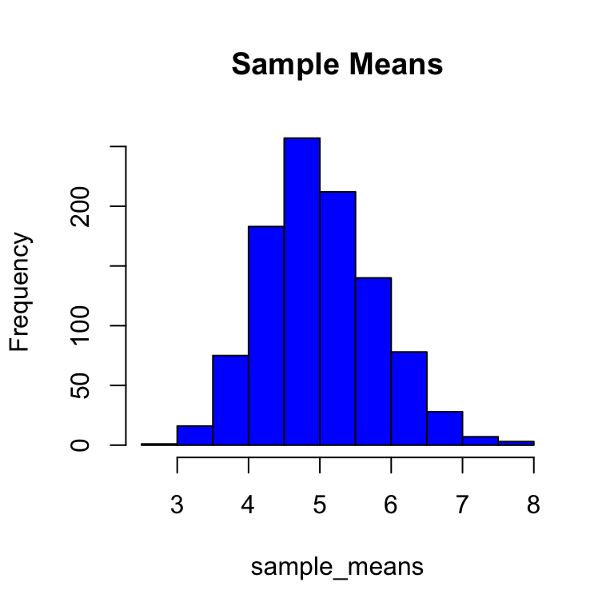

We can see from the images above that the histogram of our means can be adequately estimated with the normal distribution.

##### Compare the Confidence Intervals:

```r
conf_interval <- round (
    mean(sample_means) + c(-1,1) * 1.96 * sd(sample_means) / sqrt(n), 3
)
theoretical_conf_interval <- theoretical_mean + c(-1,1) * 1.96 * sqrt(theoretical_var) / sqrt(n);
```

We can see that the theoretical 95% confidence interval is **4.755, 5.245** and the actual confidence interval is **4.757, 5.247**. The difference between the two is minimal so we can once again say that we match really closely to the normal distribution.